# Single-cell RNA-seq: mouse enteric neuron atlas

Example report made with Claude and the BRC plugin · P01 Internal Board demo

Author

Bioinformatics Resource Center, Rockefeller University

Published

November 13, 2026

**NoteAbout this report**

Everything here was produced in a single Claude session with the **BRC plugin**, which gives Claude access to single-cell datasets hosted by the BRC (here 76 datasets) and tools to query and plot them. The prompts used are shown in each section. The two plots shown live in the P01 board demo are in sections 2 and 3.

**Data:** public dataset GSE302208 (BRC id `GSE302208_ens_atlas_geo_upload`): 7,640 mouse enteric neurons, plate-based, 22,511 genes.

## 1. What’s in the dataset?

> *“Load the ENS atlas GSE302208 and summarise it: cells, mice and genes per cell by gut region, and by condition.”*

| Gut region | Cells | Mice | Plates | Median genes per cell | 5th percentile genes per cell |
| --- | --- | --- | --- | --- | --- |
| Colon | 4068 | 39 | 127 | 6830.5 | 2204.5 |
| Ileum | 3087 | 34 | 85 | 6447.0 | 2124.0 |
| Duod_Jej | 485 | 14 | 33 | 2836.0 | 715.4 |

| Condition (as labelled) | Cells | Mice | Colon | Ileum | Duod_Jej | Median genes per cell |
| --- | --- | --- | --- | --- | --- | --- |
| SPF | 3426 | 34 | 2692 | 601 | 133 | 7204.0 |
| ASF | 861 | 3 | 527 | 334 | 0 | 6152.0 |
| OVAc | 844 | 12 | 0 | 609 | 235 | 4965.5 |
| GF | 736 | 5 | 366 | 370 | 0 | 5655.0 |
| BT | 730 | 4 | 483 | 247 | 0 | 5562.5 |
| HP_pos | 494 | 4 | 0 | 494 | 0 | 6328.0 |
| HP_neg | 275 | 4 | 0 | 275 | 0 | 6632.0 |
| OVAs | 274 | 6 | 0 | 157 | 117 | 4714.0 |

**What Claude found:** 7,640 neurons from 71 mice, from two sources: 2,410 cells from 25 mice in an earlier ENS atlas (labelled `ENS_Atlas_2021`, all SPF, Uchl1 or Sox10 reporters) and 5,230 cells from 46 mice in the current study across 8 conditions. Depth is high (median ~6,500–6,800 genes per cell in colon and ileum), as expected for plate-based sequencing. The **duodenum/jejunum** cells are the exception: median 2,836 genes per cell, less than half the other regions, so treat that region with care. Several conditions come from only 3–5 mice.

## 2. Neuron types and gut region

> *“Load the ENS atlas GSE302208 and show the UMAP coloured by cell_type_annot.”* then *“Now colour it by location.”*

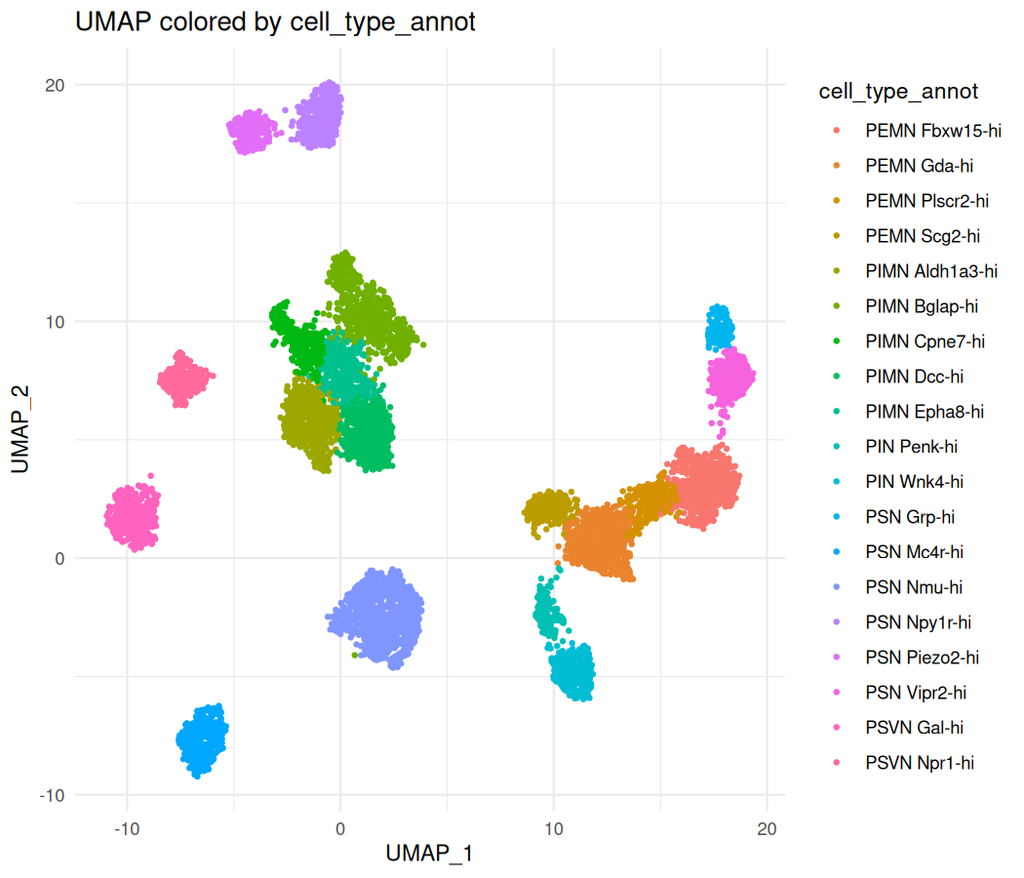

Annotated neuron types (shown in the live demo)

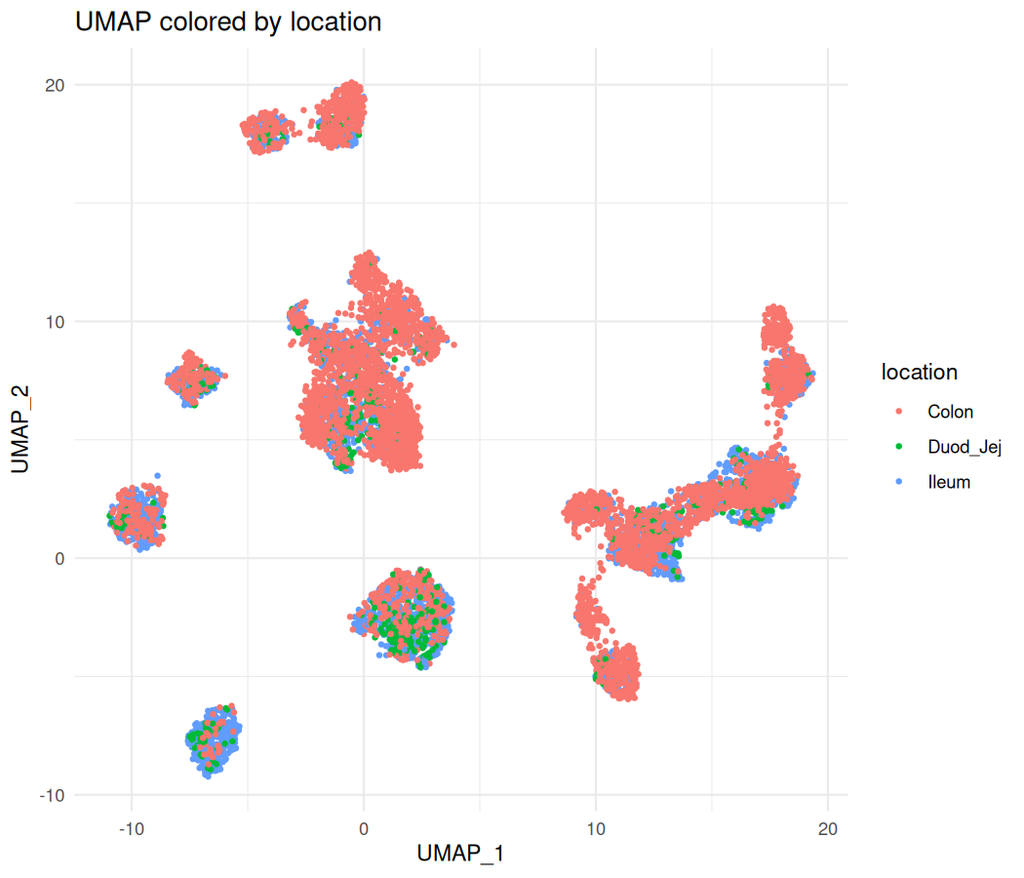

Gut region

**What Claude found:** the authors’ annotation has 19 neuron types in five classes, named by prefix: PSN (putative sensory), PEMN and PIMN (excitatory and inhibitory motor), PIN (interneurons) and PSVN (secretomotor/vasodilator). The largest group is **PSN Nmu-hi** (877 cells). Colon, ileum and duodenum/jejunum cells mix within most clusters, so the main structure is neuron type rather than gut region, although some clusters lean towards colon (section 4).

## 3. Piezo2, Nmu and Gdf15

> *“Show Piezo2, Nmu and Gdf15 as a dot plot by cell_type_annot.”* then *“Show Gdf15 as a violin plot by cell type.”*

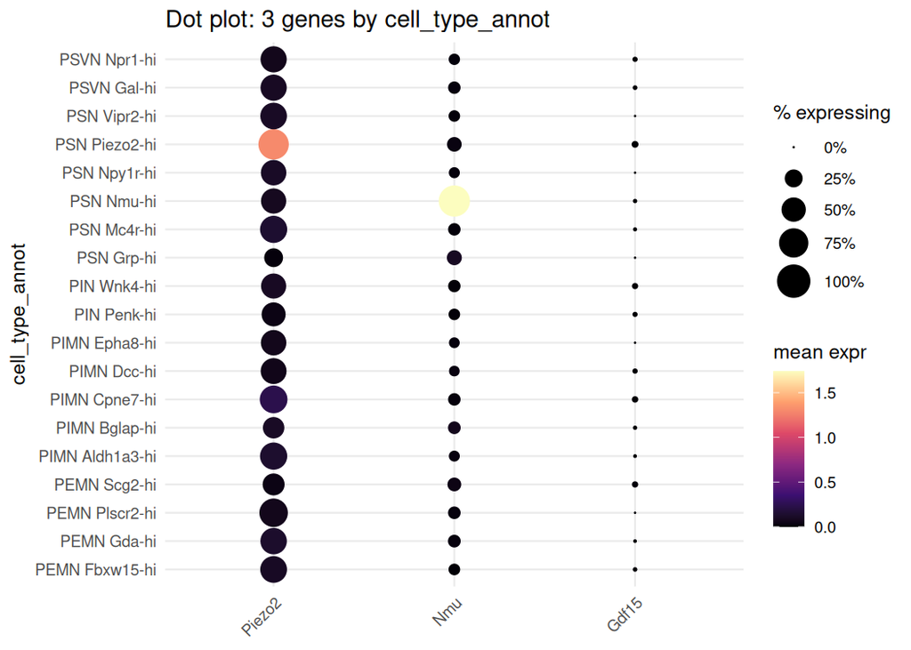

Dot size = % of cells expressing; colour = mean expression (shown in the live demo)

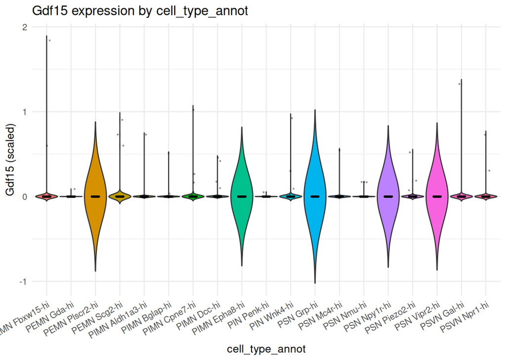

Gdf15 (scaled expression) by neuron type

**What Claude found:** the annotation checks out for the two marker genes: **Piezo2** is highest in PSN Piezo2-hi, and **Nmu** is highest in PSN Nmu-hi. **Gdf15** is close to zero in every neuron type: few cells express it and the median is zero everywhere. So in this atlas, enteric neurons are not a source of Gdf15, which fits the P01’s focus on GDF15⁺ epithelium (Project 1).

**Tip**

Absence in one dataset is not proof. These are sorted neurons only, so this says nothing about Gdf15 in epithelium or immune cells. For that, ask the same question of the whole-tissue atlas (GSE301963).

## 4. Composition by gut region

> *“What percent of each gut region’s cells is each neuron type?”*

| Neuron type | Colon % | Ileum % | Duod_Jej % |
| --- | --- | --- | --- |
| PEMN Fbxw15-hi | 8.3 | 10.3 | 9.1 |
| PEMN Gda-hi | 7.5 | 11.1 | 7.4 |
| PEMN Plscr2-hi | 4.1 | 3.1 | 2.5 |
| PEMN Scg2-hi | 4.0 | 1.3 | 0.2 |
| PIMN Aldh1a3-hi | 7.7 | 8.1 | 10.9 |
| PIMN Bglap-hi | 11.8 | 4.0 | 2.9 |
| PIMN Cpne7-hi | 4.1 | 4.2 | 3.9 |
| PIMN Dcc-hi | 9.0 | 3.4 | 6.0 |
| PIMN Epha8-hi | 6.5 | 3.3 | 5.8 |
| PIN Penk-hi | 2.9 | 0.7 | 0.2 |
| PIN Wnk4-hi | 4.8 | 2.2 | 3.7 |
| PSN Grp-hi | 3.0 | 0.2 | 0.0 |
| PSN Mc4r-hi | 0.8 | 10.7 | 6.8 |
| PSN Nmu-hi | 6.5 | 16.2 | 23.5 |
| PSN Npy1r-hi | 5.9 | 3.3 | 2.7 |
| PSN Piezo2-hi | 2.6 | 3.0 | 1.9 |
| PSN Vipr2-hi | 4.7 | 3.1 | 1.2 |
| PSVN Gal-hi | 3.0 | 8.1 | 7.0 |
| PSVN Npr1-hi | 2.9 | 3.8 | 4.3 |

**What Claude found:** some neuron types are clearly regional. **PSN Nmu-hi** and **PSN Mc4r-hi** are much more common in the small intestine (Nmu-hi 16–24% vs 6.5% in colon; Mc4r-hi 7–11% vs 0.8%). **PSN Grp-hi**, **PIN Penk-hi** and **PIMN Bglap-hi** are mostly colonic. Region is mixed with study and condition here (for example, the 2021 atlas cells are colon and SPF only), so check that a difference holds within one study before relying on it.

## What the BRC plugin did

| Step | What you ask | What happens behind the scenes |
| --- | --- | --- |
| Find data | “What single-cell datasets are available?” | Lists the 76 scRNA-seq datasets the BRC hosts |
| Load | “Load the ENS atlas GSE302208” | Activates the dataset on the BRC server |
| Summaries | “Cells and genes per cell by region”, “% of each neuron type by region” | Read-only queries of the cell metadata |
| Plots | “UMAP by cell type”, “dot plot of Piezo2, Nmu, Gdf15”, “violin of Gdf15” | The server draws the plots from the full expression data |
| Report | “Put it all in one report” | Writes this page |

The expression data never leave the BRC server. Claude only sees the summaries and plots it asks for.

**WarningBefore you use results like these**

The cell-type labels come from the depositors’ annotation; Claude did not re-cluster or re-annotate. Plate-based data, uneven numbers of mice per condition and region–study confounding all limit what can be compared. Treat these as leads, and ask the BRC for a formal analysis.